# Dropbead tutorial

Nikos Karaiskos

13 Oct 2017

# Assess basic read and downstream statistics

## Extract read statistics

`Dropbead` provides two functions to readily extract useful statistics from the data. The first one, `extractReadStatistics`, takes the BAM file as an argument and computes the total number of (uniquely mapped) reads, the percentages of intronic/intergenic etc. The output is a `data.frame` as follows:

```
##          total_reads uniq_mapped intronic intergenic coding UTR
## Drop-seq        77.6          69      4.5        0.3    4.7 3.9
##          total_barcodes
## Drop-seq            1.7
```

## Knee plot and the number of cells

`Dropbead` provides a function to computationally estimate the number of cells present in the sample, by calculating the inflection point of the cumulative fraction of reads against the cell barcodes. Assuming that `reads.by.cell` is the `data.frame` with the reads per cell (the output of `BAMTagHistogram` from the Drop-seq toolkit),

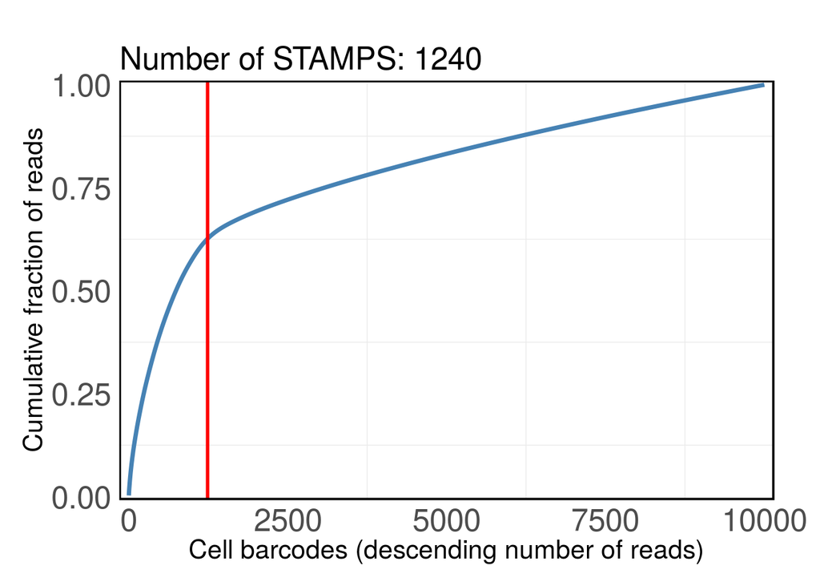

```r
plotCumulativeFractionOfReads(reads.by.cell,
                              cutoff = 10000,
                              draw.infl.point = TRUE)
```

## Extract downstream statistics

The following function creates a table with the basic downstream statistics, such as the cell number and the median number of reads, genes and UMIs per cell.

```r
extractDownstreamStatistics('~/dropseq-data/', min.umi=250, read.stats=NULL)
```

```
##   cells reads genes umis sum.umi PCR
## 1  3995  3965   351  734     4.3 5.4
```

The total number of UMIs in the DGE is given in millions. The PCR column provides the reads to UMIs ratio, so that the smaller, the better. Passing the `data.frame` output of the `extractReadStatistics` function into the `read.stats` argument provides a more precise calculation of the PCR over-amplification bias.

# Mixed species experiments

Dropbead offers two main classes to store samples, the `SingleSpeciesSample` class and the `MixedSpeciesSample` class, the latter containing the former.

Mixed species experiments are important to estimate the number of doublets in the samples. Dropbead assumes that a digital gene expression matrix (DGE) has already been generated and the genes for the two species are separated by a prefix. For mixed human/mouse samples the prefixes are `hg_` and `mm_` respectively. Assuming that the DGE has been loaded in `dge.matrix`,

```r
# The object containing the sample
mms <- new("MixedSpeciesSample",
           species1="human",
           species2="mouse",
           dge=dge.matrix)
```

The number of cells and genes are stored and automatically updated while using `dropbead`’s functions

```r
length(mms@cells) # number of cells in the sample
```

```
## [1] 1261
```

```r
length(mms@genes) # number of genes detected
```

```
## [1] 42194
```

Some of the barcodes might correspond to the same cells (essentially after using the `DetectBeadSynthesisErrors` Drop-seq tool) and have to be collapsed. Such cells are identified by

```r
listCellsToCollapse(mms)
```

```
## [[1]]
## [1] "ACCAGGAGCAAA" "ACCAGGAGCAAN"
##
## [[2]]
## [1] "GCGGTTATCAGC" "GCGGTTATCAGN"
##
## [[3]]
## [1] "TCAAGCATAATN" "TCAAGCATAATT"
##
## [[4]]
## [1] "TCACTGACAAAA" "TCACTGACAAAN"
##
## [[5]]
## [1] "CTTCCCCGCAAA" "CTTCCCCGCAAN"
```

In the example above there are 5 pairs of cells which need to be collapsed. This is straightforward with using

```r
mms <- collapseCellsByBarcode(mms)
```

We can verify that the number of cells is now the correct one

```r
length(mms@cells)
```

```
## [1] 1256
```

## Handling mixed species samples

Calling `classifyCellsAndDoublets` separates the species and returns a `data.frame` with number of transcripts per cell per species. The `threshold` controls the purity of the resulting cells, while `min.trans` is the minimum number of UMIs required to keep a cell.

```r
head(classifyCellsAndDoublets(mms,
                              threshold = 0.9,
                              min.trans = 1000))
```

```
##           cell human mouse species
## 1 TTGAGACGGATA 33587   486   human
## 2 TTGCAGCCACCT 32838   458   human
## 3 GCTTCAGACAGA 31838   420   human
## 4 CTCTTCATCGAG 28476   296   human
## 5 TAACACACCGTG   511 32516   mouse
## 6 AGCTGCCGTTTG   546 31010   mouse
```

The output of `classifyCellsAndDoublets` can be directly send for plotting

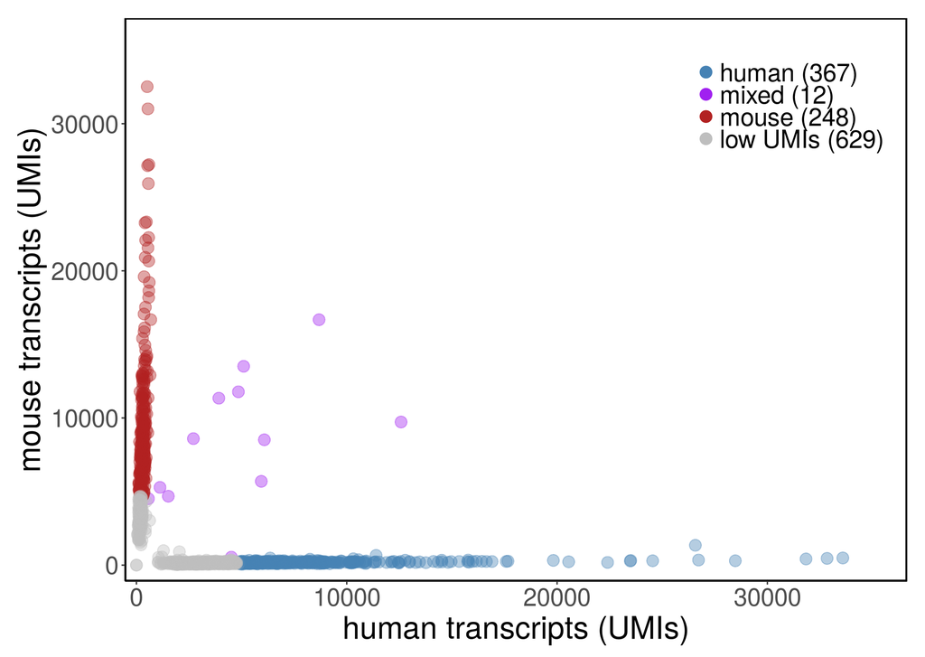

```r
plotCellTypes(classifyCellsAndDoublets(mms, threshold = 0.9, min.trans = 5000))
```

The number of genes per cell is computed via

```r
head(computeGenesPerCell(mms))
```

```
##          cells counts species
## 1 TTGAGACGGATA   7600   human
## 2 TTGCAGCCACCT   7582   human
## 3 GCTTCAGACAGA   7554   human
## 4 CTCTTCATCGAG   7263   human
## 5 GCTTACTATCCG   6830   human
## 6 AACTGGTTCGTC   6685   human
```

and similarly for transcripts (UMIs) with the `computeTranscriptsPerCell` function. Their output can be send directly for plotting and visualization

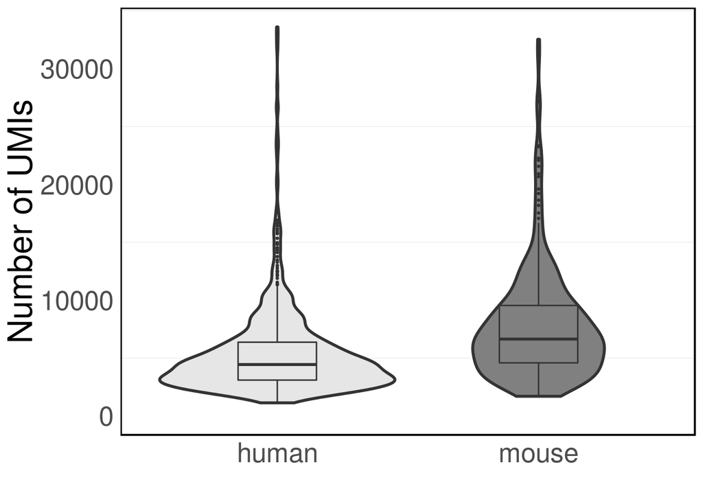

```r
plotViolin(computeTranscriptsPerCell(mms),
           attribute = "UMIs")
```

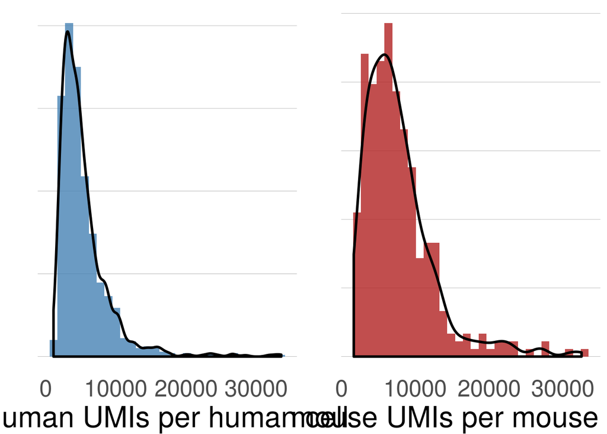

```r
plotHistogram(computeTranscriptsPerCell(mms),
              attribute = 'UMIs')
```

The above functions are polymorphic and can be also used for `SingleSpeciesSample` objects. Splitting the samples is always performed by internal functions automatically. If the user wants to restrict to only one species, this is done by the `splitMixedSpeciesSampleToSingleSpecies` function. which returns a list of the two `SingleSpeciesSample` objects.

```r
# Extracting the human cells as a separate sample for further analysis
h <- splitMixedSpeciesSampleToSingleSpecies(mms,
                                            threshold = 0.9)[[1]]
class(h)
```

```
## [1] "SingleSpeciesSample"
## attr(,"package")
## [1] "dropbead"
```

# Single species

## Filtering functions

There are a couple of functions to remove low quality cells and genes, such as

```r
h.f1 <- keepBestCells(h, num.cells = 100) # keep only the top 100 cells
h.f2 <- keepBestCells(h, min.num.trans = 1000) # keep cells with at least 1000 UMIs
h.f3 <- removeLowQualityCells(h, min.genes = 2000) # remove cells which don't express at least 2000 genes
h.f4 <- removeLowQualityGenes(h, min.cells = 3) # remove genes which are not expressed in at least 3 cells
```

with obvious usage.

## Comparing gene expression measurements

Reproducibility and correlations of different samples are easily assessed via the `compareGeneExpressionLevels` function, for instance,

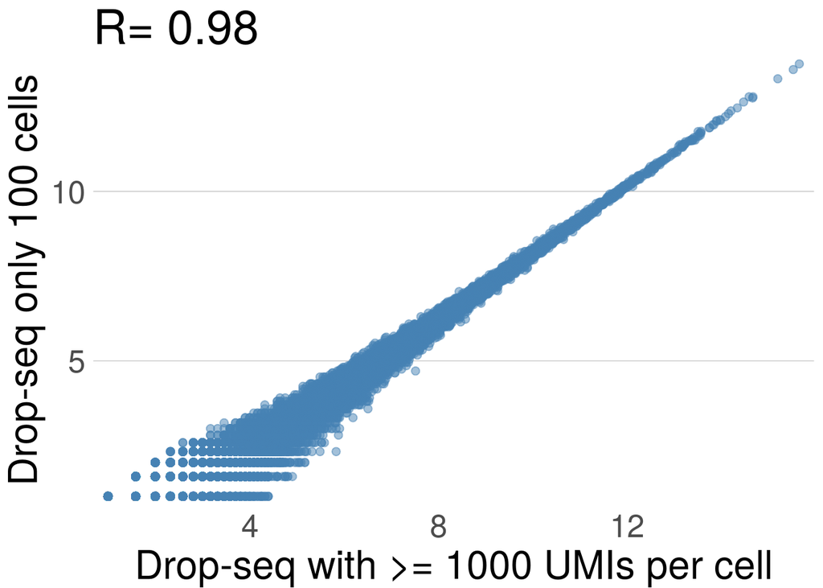

```r
compareGeneExpressionLevels(h.f2, h.f1,
                            name1 = 'Drop-seq with >= 1000 UMIs per cell',
                            name2 = 'Drop-seq only 100 cells',
                            method = 'pearson')
```

If bulk data is available then its correlation pwith the Drop-seq sample is directly assessed with the function `compareSingleCellsAgainstBulk`. Note that bulk has to be in a 1-column `data.frame` format with genes as the `rownames` and RPKM values (as default, raw counts are also accepted)

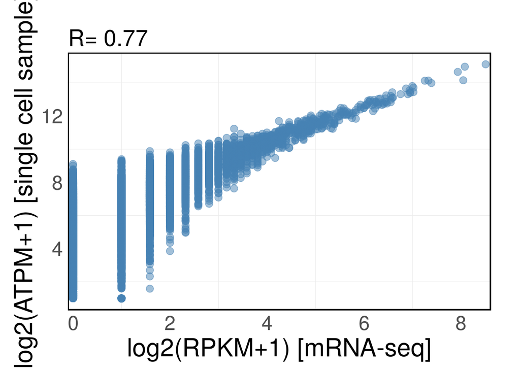

```r
compareSingleCellsAgainstBulk(h.f1,
                              log2(h.f2@dge[, 1, drop=F]+1))
```

## Further exploration

It is instructive to assess the mitochondrial content of the single cell samples. This is done as below and the percentages can be sent for plotting

```r
head(computeMitochondrialPercentage(h), 5)
```

```
## TTGAGACGGATA TTGCAGCCACCT GCTTCAGACAGA CTCTTCATCGAG GCTTACTATCCG
##     3.227439     2.512333     3.813054     3.827785     3.051626
```

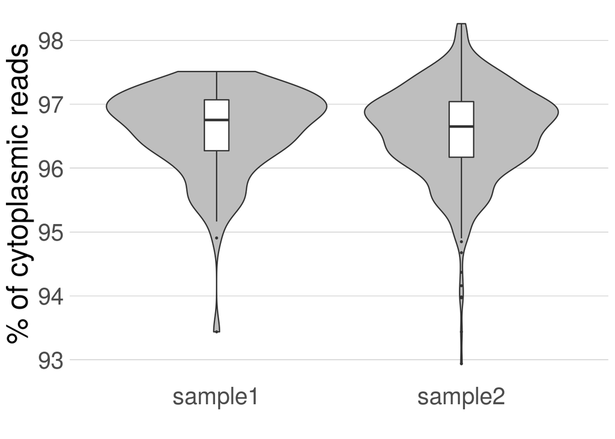

```r
plotMitochondrialContent(list(100-computeMitochondrialPercentage(h.f1),
                              100-computeMitochondrialPercentage(h.f3)),
                         log_scale = FALSE)
```

`Dropbead` offers also an implementation of the algorithm described in Macosko et. al. 2015 for classification of the cell cycle phases. The following R-packages `xlsx`, `rJava` and `xlsxjars` are required for this

```r
phases <- assignCellCyclePhases(h)
```

[figure not shown]